# 연도별 주제 흐름 변화, 야놀자 중심으로

2022-11-08

> - 기간: 2020.01.01 ~ 2020.12.31
> - 기간: 2021.01.01 ~ 2021.12.31
> - 기간: 2022.01.01 ~ 2022.10.31

> 빅카인즈 키워드 검색을 통해 2020년, 2021년, 2022년에 해당하는 데이터들을 수집함

> ’야놀자’를 중심으로 20년 1,147건, 21년 2,148건, 22년 1,518건을 분석한다.

> 각 연도별 총빈도수와 주제의 변화를 알아보고자 한다.

### 1. 분석에 앞선 기본적인 준비

##### 1) 패키지 설치 및 불러오기

**패키지 불러오기**

```r
c( "rio", "psych", "psychTools", "skimr", "janitor",

   "tidyverse", "tidytable", "tidymodels", "lm.beta",

   "GGally", "ggforce", "gt", "mdthemes", "patchwork",

   "r2symbols", "equatiomatic", "purrr", "palmerpenguins",

   "textdata", "tidytext", "epubr", "stm", "quarto", "wordcloud",

   "RcppMeCab", "KoNLP", "tidyr", "dplyr", "tidylo", "lubridate"

) -> pkg

lapply(pkg, require, ch = T)
```

[output not shown]

[output not shown]

[output cut: 34 more lines]

[output not shown]

```r
sapply(pkg, function(x){

  if(!require(x, ch = T)) install.packages(x)

  library(x, ch = T)

})
```

[output not shown]

[output cut: 433 more lines]

##### 2) 파일 경로 설정

**파일경로 설정**

```r
setwd("C:/Users/YH JUNG/Documents/R/GIT/residence/data")

getwd()
```

```
## [1] "C:/Users/YH JUNG/Documents/R/GIT/residence/data"
```

##### 3) 자료 불러오기 및 자료 정제

**빅카인즈 야놀자 연도별 자료**

```r
# 야놀자 2020
yanolja2020_df <- readxl::read_excel("C:/Users/YH JUNG/Documents/R/GIT/residence/data/NewsResult_20200101-20201231.xlsx") %>%

select.(제목, 언론사, 본문, 일자)

yanolja2020_tk <- yanolja2020_df %>%

drop_na() %>%

unnest_tokens(word, 제목, token = pos) %>%

separate(word, c("word", "pos"), sep = "/") %>%

filter(pos == 'nng')

# 야놀자 2021
yanolja2021_df <- readxl::read_excel("C:/Users/YH JUNG/Documents/R/GIT/residence/data/NewsResult_20210101-20211231.xlsx") %>%

select.(제목, 언론사, 본문, 일자)

yanolja2021_tk <- yanolja2021_df %>%

drop_na() %>%

unnest_tokens(word, 제목, token = pos) %>%

separate(word, c("word", "pos"), sep = "/") %>%

filter(pos == 'nng')

# 야놀자 2022
yanolja2022_df <- readxl::read_excel("C:/Users/YH JUNG/Documents/R/GIT/residence/data/NewsResult_20220101-20221031.xlsx") %>%

select.(제목, 언론사, 본문, 일자)

yanolja2022_tk <- yanolja2022_df %>%

drop_na() %>%

unnest_tokens(word, 제목, token = pos) %>%

separate(word, c("word", "pos"), sep = "/") %>%

filter(pos == 'nng')
```

### 2. 총빈도 & 상대빈도

#### 1) 총빈도

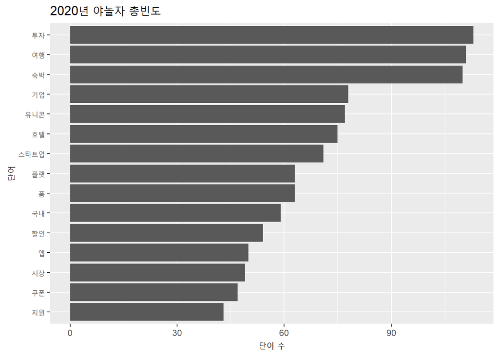

```r
yanolja2020_total <- yanolja2020_tk %>%

count(word, sort = T) %>%

slice_max(n, n = 15) %>%

ggplot(aes(x = n,

y = reorder(word, n))) +

geom_col(show.legend = F) +

 labs(x = "단어 수", y = "단어",
       title = "2020년 야놀자 총빈도")

yanolja2020_total
```

2020년은 투자, 여행, 숙박 관련된 단어가 주를 이루었다.

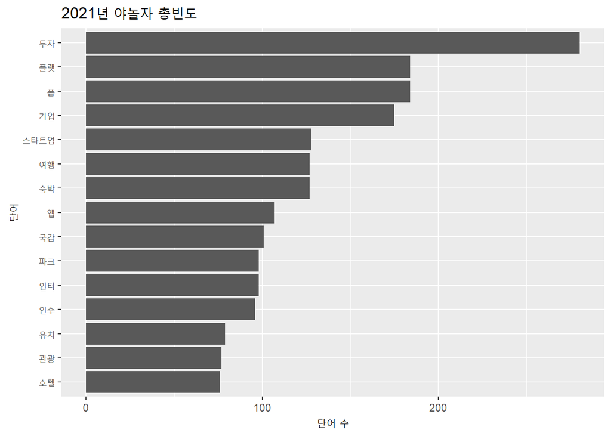

```r
yanolja2021_total <- yanolja2021_tk %>%

count(word, sort = T) %>%

slice_max(n, n = 15) %>%

ggplot(aes(x = n,

y = reorder(word, n))) +

geom_col(show.legend = F) +

   labs(x = "단어 수", y = "단어",
       title = "2021년 야놀자 총빈도")

yanolja2021_total
```

2021년도 2020년과 마찬가지로 투자가 주를 이루었지만, 2020년보다도 더 깊게 이야기가 나왔다. 야놀자의 플랫폼, 기업, 스타트업 등과 같은 내용이 여행보다도 많이 나온 것으로 보아 2021년도의 야놀자는 이러한 내용이 주를 이룬 것으로 보인다.

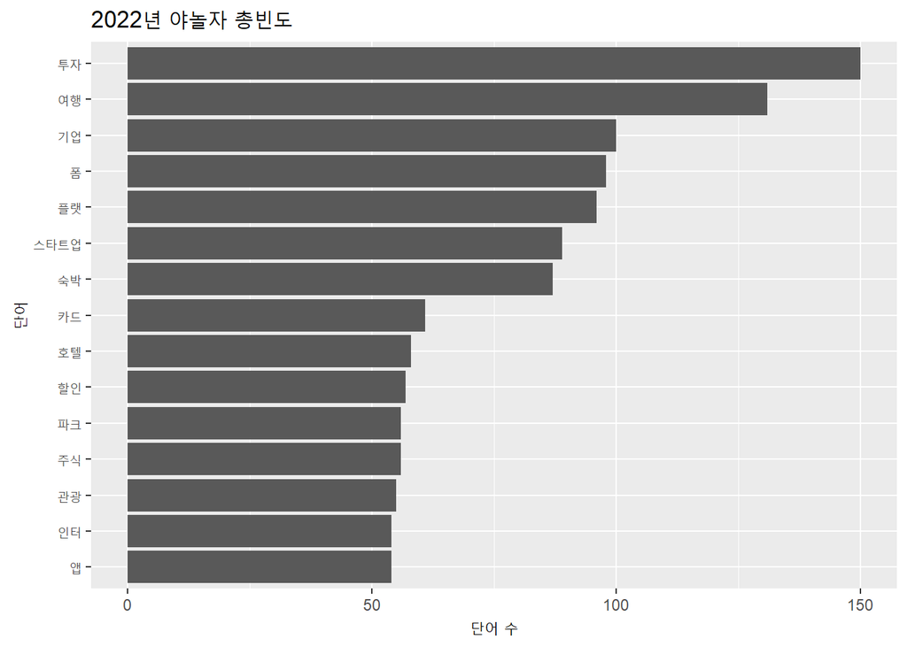

```r
yanolja2022_total <- yanolja2022_tk %>%

count(word, sort = T) %>%

slice_max(n, n = 15) %>%

ggplot(aes(x = n,

y = reorder(word, n))) +

geom_col(show.legend = F) +

 labs(x = "단어 수", y = "단어",
       title = "2022년 야놀자 총빈도")

yanolja2022_total
```

2022년도의 단어는 2020년도의 단어와 유사한 것으로 보여진다.

#### 2) 상대빈도

**상대빈도 2020 & 2021**

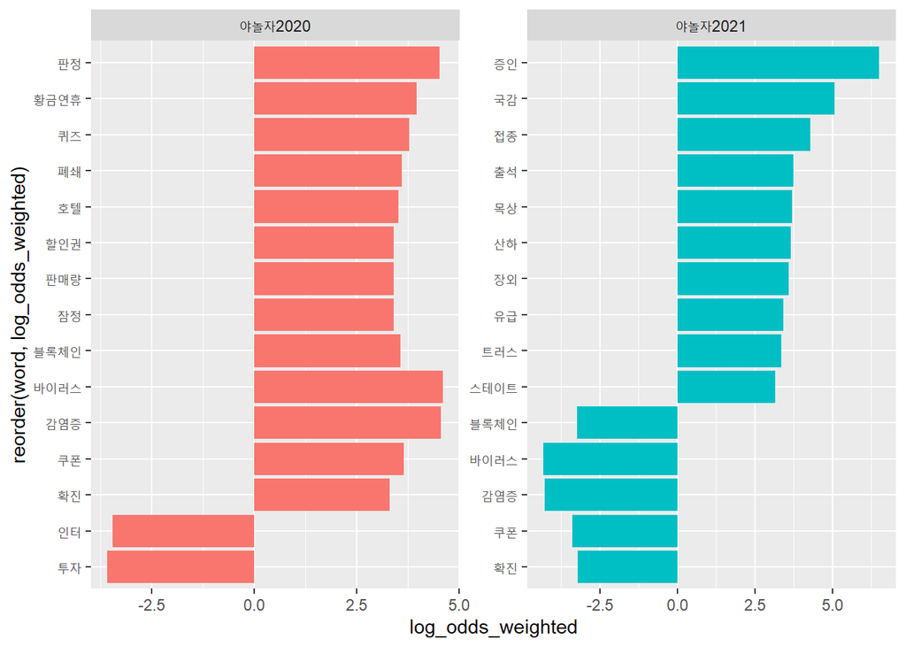

```r
yanolja2020_df %>%
  unnest_tokens(output = word, input = 본문, token  = pos) %>%
  separate(col = word,
           into = c("word", "pos"),
           sep = "/") %>%
  filter(pos == "nng")-> yj2020_df

yanolja2021_df %>%
  unnest_tokens(output = word, input = 본문, token  = pos) %>%
  separate(col = word,
           into = c("word", "pos"),
           sep = "/") %>%
  filter(pos == "nng")-> yj2021_df

#상대빈도 결합
bind_rows(yj2020_df, yj2021_df, .id = "기업")  %>%
  filter(str_length(word) > 1) %>%
  filter(word != "야놀자") %>%
  count(word, 기업) %>%
  bind_log_odds(set = 기업,
                feature = word,
                n = n) %>%
  arrange(-log_odds_weighted) -> weighted_log_odds01_df

weighted_log_odds01_df %>%
  group_by(기업 = ifelse(기업 > 1, "야놀자2021", "야놀자2020")) %>%
  slice_max(abs(log_odds_weighted), n = 15) %>%
  ggplot(aes(x = log_odds_weighted,
             y = reorder(word, log_odds_weighted),
             fill = 기업)) +
  geom_col(show.legend = F) +
  facet_wrap(~기업, scale = "free")
```

20년도에서 21년도에 들어오며 눈에 띄는 상대적 단어를 살펴본다. 20년도는 코로나의 발발로 바이러스, 감염증, 확진과 같은 단어들이 많이 나타난 것으로 보인다. 눈에 띄는 기술로는 블록체인이 있는데 코로나 이전 유행한 코인의 흐름을 야놀자도 함께 탄 것이다. 21년도에는 야놀자가 논란의 중심이 되었던 숙박어플리케이션 불법행위 조장과 수수료 책정 문제와 관련한 질의를 국정감사에서 답변한다는 기사가 중심이 되었다.

**상대빈도 2021 & 2022**

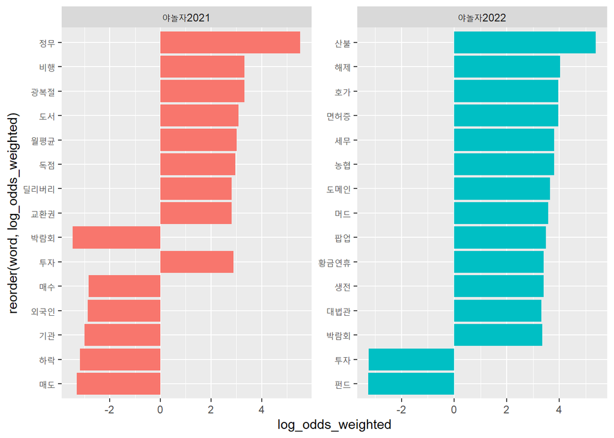

```r
yanolja2022_df %>%
  unnest_tokens(output = word, input = 본문, token  = pos) %>%
  separate(col = word,
           into = c("word", "pos"),
           sep = "/") %>%
  filter(pos == "nng")-> yj2022_df

#상대빈도 결합
bind_rows(yj2021_df, yj2022_df, .id = "기업")  %>%
  filter(str_length(word) > 1) %>%
  filter(word != "야놀자") %>%
  count(word, 기업) %>%
  bind_log_odds(set = 기업,
                feature = word,
                n = n) %>%
  arrange(-log_odds_weighted) -> weighted_log_odds12_df

weighted_log_odds12_df %>%
  group_by(기업 = ifelse(기업 > 1, "야놀자2022", "야놀자2021")) %>%
  slice_max(abs(log_odds_weighted), n = 15) %>%
  ggplot(aes(x = log_odds_weighted,
             y = reorder(word, log_odds_weighted),
             fill = 기업)) +
  geom_col(show.legend = F) +
  facet_wrap(~기업, scale = "free")
```

21년도 국정 감사가 주된 내용을 이루었다면, 22년에는 주식과 함께 산불관련 내용이 중심을 이루었다. 2022년 야놀자는 강원도 산불을 ESG 캠페인으로 지원하여 자신의 이미지를 변화시켰다.

### 3. 주제모형

> 모형 구축을 위해 기준점이 되는 자료 열 “press”, “cat” 등을 새롭게 불러와 자료를 수집하고

> 수집한 기사의 중복 기사를 삭제하고 기사별 열 번호를 기입하여 분석에 용의하게 정제했다.

> 많은 주제 중 경제와 문화 측면의 기사가 가장 많아 경제로 묶었다.

> 다양한 언론사를 야당지와 여당지로 추가 분류하였고 속하지 않은 언론사는 여당지로 분류하였다.

**자료 정제**

##### 1) 모델링을 위한 자료 수집

```r
#야놀자
yanolja2020_sub <- readxl::read_excel("C:/Users/YH JUNG/Documents/R/GIT/residence/data/NewsResult_20200101-20201231.xlsx") %>%
select(일자, 제목, 본문, 언론사, cat = `통합 분류1`, 키워드)

#야놀자
yanolja2021_sub <- readxl::read_excel("C:/Users/YH JUNG/Documents/R/GIT/residence/data/NewsResult_20210101-20211231.xlsx") %>%
select(일자, 제목, 본문, 언론사, cat = `통합 분류1`, 키워드)

#야놀자
yanolja2022_sub <- readxl::read_excel("C:/Users/YH JUNG/Documents/R/GIT/residence/data/NewsResult_20220101-20221031.xlsx") %>%
select(일자, 제목, 본문, 언론사, cat = `통합 분류1`, 키워드)
```

##### 2) 자료 정제

**야놀자 자료 정제**

```r
## 야놀자 2020 자료 정제
yanolja2020_sub2 <- yanolja2020_sub %>%

distinct(제목, .keep_all = T) %>%

mutate(ID = factor(row_number())) %>%

mutate(date = ymd(일자)) %>%

mutate(year = year(date)) %>%

mutate(month = month(date)) %>%

mutate(day = day(date)) %>%

unite(제목, 본문, col = "text", sep = " ") %>%

mutate(text = str_squish(text)) %>%

mutate(press = case_when(

언론사 == "조선일보" ~ "야당지",

언론사 == "중앙일보" ~ "야당지",

언론사 == "동앙일보" ~ "야당지",

언론사 == "국민일보" ~ "야당지",

언론사 == "문화일보" ~ "야당지",

언론사 == "한국경제" ~ "야당지",

언론사 == "경향신문" ~ "여당지",

TRUE ~ "여당지") ) %>%

separate(cat, sep = ">", into = c("cat", "cat2")) %>%

select(-cat2) %>%

mutate(catSoc = case_when( cat == "경제" ~ "경제면",
                           cat == "문화" ~ "경제면",
                           TRUE ~ "비경제면") )

## 야놀자 2021 자료 정제
yanolja2021_sub2 <- yanolja2021_sub %>%

distinct(제목, .keep_all = T) %>%

mutate(ID = factor(row_number())) %>%

mutate(date = ymd(일자)) %>%

mutate(year = year(date)) %>%

mutate(month = month(date)) %>%

mutate(day = day(date)) %>%

unite(제목, 본문, col = "text", sep = " ") %>%

mutate(text = str_squish(text)) %>%

mutate(press = case_when(

언론사 == "조선일보" ~ "야당지",

언론사 == "중앙일보" ~ "야당지",

언론사 == "동앙일보" ~ "야당지",

언론사 == "국민일보" ~ "야당지",

언론사 == "문화일보" ~ "야당지",

언론사 == "한국경제" ~ "야당지",

언론사 == "경향신문" ~ "여당지",

TRUE ~ "여당지") ) %>%

separate(cat, sep = ">", into = c("cat", "cat2")) %>%

select(-cat2) %>%

mutate(catSoc = case_when( cat == "경제" ~ "경제면",
                           cat == "문화" ~ "경제면",
                           TRUE ~ "비경제면") )

## 야놀자 2022 자료 정제
yanolja2022_sub2 <- yanolja2022_sub %>%

distinct(제목, .keep_all = T) %>%

mutate(ID = factor(row_number())) %>%

mutate(date = ymd(일자)) %>%

mutate(year = year(date)) %>%

mutate(month = month(date)) %>%

mutate(day = day(date)) %>%

unite(제목, 본문, col = "text", sep = " ") %>%

mutate(text = str_squish(text)) %>%

mutate(press = case_when(

언론사 == "조선일보" ~ "야당지",

언론사 == "중앙일보" ~ "야당지",

언론사 == "동앙일보" ~ "야당지",

언론사 == "국민일보" ~ "야당지",

언론사 == "문화일보" ~ "야당지",

언론사 == "한국경제" ~ "야당지",

언론사 == "경향신문" ~ "여당지",

TRUE ~ "여당지") ) %>%

separate(cat, sep = ">", into = c("cat", "cat2")) %>%

select(-cat2) %>%

mutate(catSoc = case_when( cat == "경제" ~ "경제면",
                           cat == "문화" ~ "경제면",
                           TRUE ~ "비경제면") )
```

##### 3) 토큰화

**야놀자 토큰화**

```r
fullchar_v <- "ㆍ|ㅣ|‘|’|“|”|○|●|◎|◇|◆|□|■|△|▲|▽|▼|〓|◁|◀|▷|▶|♤|♠|♡|♥|♧|♣|⊙|◈|▣"


#야놀자 토큰화 2020
yanolja2020_S <- yanolja2020_sub2 %>%

mutate(키워드 = str_remove_all(키워드, "[^(\\w+|\\d+|,)]")) %>%

mutate(키워드 = str_remove_all(키워드, fullchar_v)) %>%

unnest_tokens(word, 키워드, token = "regex", pattern = ",")

#토큰화 후 데이터 결합

yanolja2020_C <- yanolja2020_S %>%

group_by(ID) %>%

summarise(text2 = str_flatten(word, " ")) %>%

ungroup() %>%

inner_join(yanolja2020_sub2, by = "ID")

#야놀자 토큰화 2021
yanolja2021_S <- yanolja2021_sub2 %>%

mutate(키워드 = str_remove_all(키워드, "[^(\\w+|\\d+|,)]")) %>%

mutate(키워드 = str_remove_all(키워드, fullchar_v)) %>%

unnest_tokens(word, 키워드, token = "regex", pattern = ",")

#토큰화 후 데이터 결합

yanolja2021_C <- yanolja2021_S %>%

group_by(ID) %>%

summarise(text2 = str_flatten(word, " ")) %>%

ungroup() %>%

inner_join(yanolja2021_sub2, by = "ID")

#야놀자 토큰화 2022
yanolja2022_S <- yanolja2022_sub2 %>%

mutate(키워드 = str_remove_all(키워드, "[^(\\w+|\\d+|,)]")) %>%

mutate(키워드 = str_remove_all(키워드, fullchar_v)) %>%

unnest_tokens(word, 키워드, token = "regex", pattern = ",")

#토큰화 후 데이터 결합

yanolja2022_C <- yanolja2022_S %>%

group_by(ID) %>%

summarise(text2 = str_flatten(word, " ")) %>%

ungroup() %>%

inner_join(yanolja2022_sub2, by = "ID")
```

##### 4) stm 말뭉치

**2020년 야놀자 stm**

```r
#2020년 야놀자 stm 말뭉치
processed2020_yanol <- yanolja2020_C %>%
  textProcessor(documents = yanolja2020_C$text2,
                metadata = .,
                wordLengths = c(2, Inf))
```

```
## Building corpus...
## Converting to Lower Case...
## Removing punctuation...
## Removing stopwords...
## Removing numbers...
## Stemming...
## Creating Output...
```

```r
out2020_yanol <- prepDocuments(processed2020_yanol$documents,
                           processed2020_yanol$vocab,
                           processed2020_yanol$meta,
                           lower.thresh = 0)


# 모형구축을 위한 객체 저장
docs2020_yanol <- out2020_yanol$documents

vocab2020_yanol <- out2020_yanol$vocab

meta2020_yanol <- out2020_yanol$meta
```

**2021년 야놀자 stm**

```r
#2021년 야놀자 stm 말뭉치
processed2021_yanol <- yanolja2021_C %>%
  textProcessor(documents = yanolja2021_C$text2,
                metadata = .,
                wordLengths = c(2, Inf))
```

```
## Building corpus...
## Converting to Lower Case...
## Removing punctuation...
## Removing stopwords...
## Removing numbers...
## Stemming...
## Creating Output...
```

```r
out2021_yanol <- prepDocuments(processed2021_yanol$documents,
                           processed2021_yanol$vocab,
                           processed2021_yanol$meta,
                           lower.thresh = 0)


# 모형구축을 위한 객체 저장
docs2021_yanol <- out2021_yanol$documents

vocab2021_yanol <- out2021_yanol$vocab

meta2021_yanol <- out2021_yanol$meta
```

**2022년 야놀자 stm**

```r
#2021년 야놀자 stm 말뭉치
processed2022_yanol <- yanolja2022_C %>%
  textProcessor(documents = yanolja2022_C$text2,
                metadata = .,
                wordLengths = c(2, Inf))
```

```
## Building corpus...
## Converting to Lower Case...
## Removing punctuation...
## Removing stopwords...
## Removing numbers...
## Stemming...
## Creating Output...
```

```r
out2022_yanol <- prepDocuments(processed2022_yanol$documents,
                           processed2022_yanol$vocab,
                           processed2022_yanol$meta,
                           lower.thresh = 0)


# 모형구축을 위한 객체 저장
docs2022_yanol <- out2022_yanol$documents

vocab2022_yanol <- out2022_yanol$vocab

meta2022_yanol <- out2022_yanol$meta
```

##### 5) 공변인 분석

**야놀자 주제모형(공변인) 분석**

```r
#시스템 시간
t1 <- Sys.time()
t2 <- Sys.time()
#주제모형 2020년구성
meta_fit_yanol2020 <- stm(documents = docs2020_yanol,
                      vocab = vocab2020_yanol,
                      data = meta2020_yanol,
                      K = 10,
                      prevalence =~ press + s(month, 12),
                      max.em.its = 75,
                      verbose = F,
                      init.type = "Spectral",
                      seed = 37)

meta_fit_yanol2021 <- stm(documents = docs2021_yanol,
                      vocab = vocab2021_yanol,
                      data = meta2021_yanol,
                      K = 10,
                      prevalence =~ press + s(month, 12),
                      max.em.its = 75,
                      verbose = F,
                      init.type = "Spectral",
                      seed = 37)

meta_fit_yanol2022 <- stm(documents = docs2022_yanol,
                      vocab = vocab2022_yanol,
                      data = meta2022_yanol,
                      K = 10,
                      prevalence =~ press + s(month, 12),
                      max.em.its = 75,
                      verbose = F,
                      init.type = "Spectral",
                      seed = 37)
```

##### 6) 주제 이름 짓기

**야놀자 주제이름 짓기**

```r
#주제 이름 데이터 프레임에 저장
topic_name_yanol2022 <- tibble(topic = 1:10,
                           name = c("1. 크롤링 논란",
                                    "2. 인터파크 인수",
                                    "3. 여행",
                                    "4. 산불지원",
                                    "5. 광고",
                                    "6. 할인",
                                    "7. 국정감사",
                                    "8. 이벤트",
                                    "9. 유니콘기업",
                                    "10. 투자") )

topic_name_yanol2021 <- tibble(topic = 1:10,
                           name = c("1. 할인",
                                    "2. 국정감사",
                                    "3. 유니콘기업",
                                    "4. NFT",
                                    "5. 주식",
                                    "6. 인터파크 인수",
                                    "7. 관광",
                                    "8. 투자",
                                    "9. 광고",
                                    "10. 여행") )

topic_name_yanol2020 <- tibble(topic = 1:10,
                           name = c("1. 코로나",
                                    "2. 플랫폼법",
                                    "3. 광고",
                                    "4. 프롭테크",
                                    "5. 여행",
                                    "6. 야놀자 골프",
                                    "7. 클라우드 서비스",
                                    "8. 할인",
                                    "9. 블록체인",
                                    "10. 유니콘기업") )
```

##### 7) 주제별 단어 분포표

**야놀자 주제별 단어 분포표**

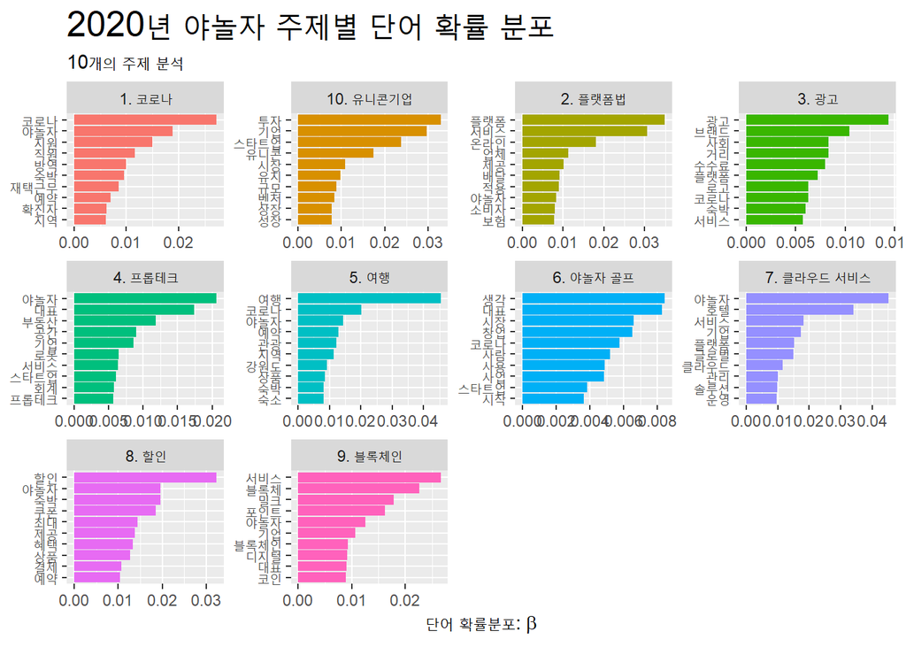

```r
term_topic_name_yanol2020 %>%
  ggplot(aes(x = beta,
             y = reorder_within(term, beta, name),
             fill = name)) +
  geom_col(show.legend = F) +

  facet_wrap(~name, scales = "free") +

  scale_y_reordered() +

  labs(x = expression("단어 확률분포:"~beta), y = NULL,
       title = "2020년 야놀자 주제별 단어 확률 분포",
       subtitle = "10개의 주제 분석") +

  theme(plot.title = element_text(size = 20))
```

> 2020년도에는 블록체인, 유니콘 기업, 코로나, 클라우드 서비스가 높은 분포를 보였다.

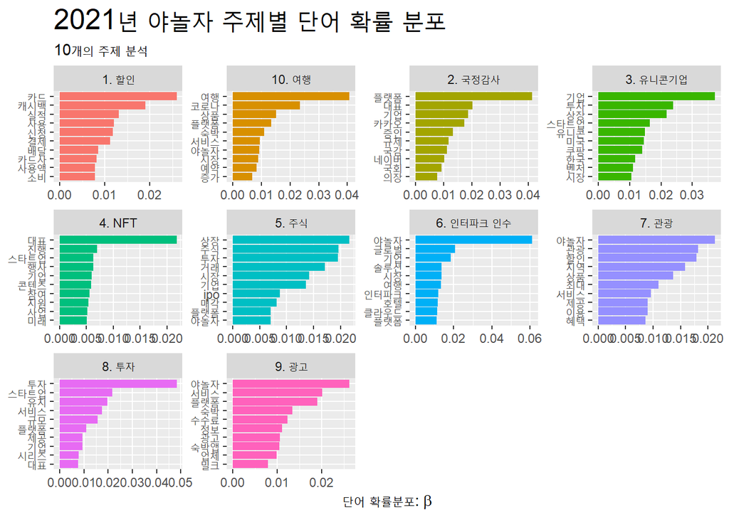

```r
term_topic_name_yanol2021 %>%
  ggplot(aes(x = beta,
             y = reorder_within(term, beta, name),
             fill = name)) +
  geom_col(show.legend = F) +

  facet_wrap(~name, scales = "free") +

  scale_y_reordered() +

  labs(x = expression("단어 확률분포:"~beta), y = NULL,
       title = "2021년 야놀자 주제별 단어 확률 분포",
       subtitle = "10개의 주제 분석") +

  theme(plot.title = element_text(size = 20))
```

> 2021년도에는 인터파크 인수, 유니콘 기업, 투자에서 단어 분포가 높게 나타났다.

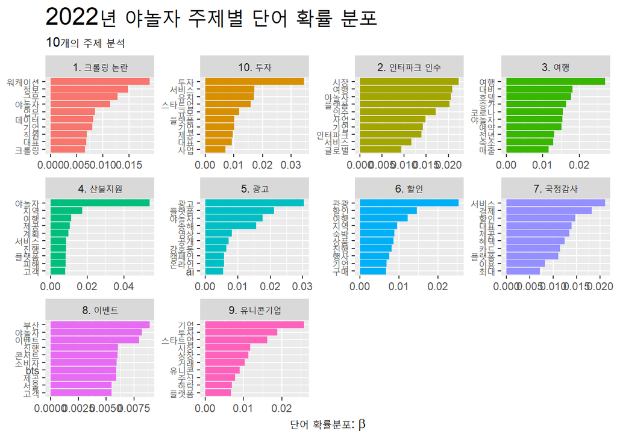

```r
term_topic_name_yanol2022 %>%
  ggplot(aes(x = beta,
             y = reorder_within(term, beta, name),
             fill = name)) +
  geom_col(show.legend = F) +

  facet_wrap(~name, scales = "free") +

  scale_y_reordered() +

  labs(x = expression("단어 확률분포:"~beta), y = NULL,
       title = "2022년 야놀자 주제별 단어 확률 분포",
       subtitle = "10개의 주제 분석") +

  theme(plot.title = element_text(size = 20))
```

> 2022년에는 산불지원, 투자, 광고의 단어확률 분포가 높았다.

##### 8) 상위 주제어

**야놀자 감마 분석을 통한 상위 주제어**

**상위 주제어 그래프 2020년**

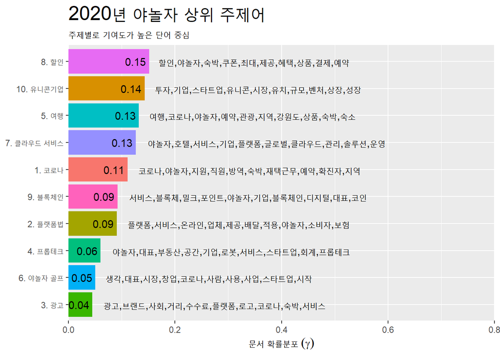

```r
##2020
gamma_terms_yanol2020 %>%

  ggplot(aes(x = gamma, y = reorder(name, gamma), fill = name)) +

  geom_col(show.legend = F) +

  geom_text(aes(label = round(gamma, 2)),
            hjust = 1.15) +

  geom_text(aes(label = terms),
            hjust = -0.05) +

  scale_x_continuous(expand = c(0, 0),
                     limit = c(0, .8)) +

  labs(x = expression("문서 확률분포"~(gamma)),
       y = NULL,
       title = "2020년 야놀자 상위 주제어",
       subtitle = "주제별로 기여도가 높은 단어 중심") +

  theme(plot.title = element_text(size = 20))
```

2020년 상위 주제어 그래프에서는 할인, 유니콘 기업, 강원도 여행, 클라우드 서비스의 기여도 높은 단어가 많았다.

**상위 주제어 그래프 2021년**

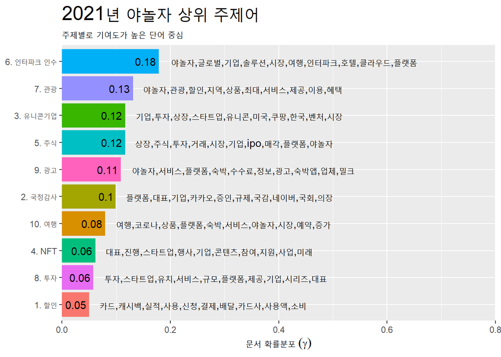

```r
##2021
gamma_terms_yanol2021 %>%

  ggplot(aes(x = gamma, y = reorder(name, gamma), fill = name)) +

  geom_col(show.legend = F) +

  geom_text(aes(label = round(gamma, 2)),
            hjust = 1.15) +

  geom_text(aes(label = terms),
            hjust = -0.05) +

  scale_x_continuous(expand = c(0, 0),
                     limit = c(0, .8)) +

  labs(x = expression("문서 확률분포"~(gamma)),
       y = NULL,
       title = "2021년 야놀자 상위 주제어",
       subtitle = "주제별로 기여도가 높은 단어 중심") +

  theme(plot.title = element_text(size = 20))
```

2021년에는 인터파크 인수, 관광, 유니콘 기업, 주식 순으로 단어 기여도가 높았다.

**상위 주제어 그래프 2022년**

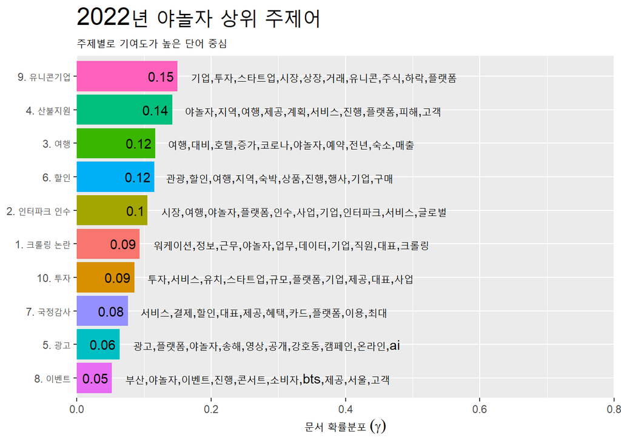

```r
##2022
gamma_terms_yanol2022 %>%

  ggplot(aes(x = gamma, y = reorder(name, gamma), fill = name)) +

  geom_col(show.legend = F) +

  geom_text(aes(label = round(gamma, 2)),
            hjust = 1.15) +

  geom_text(aes(label = terms),
            hjust = -0.05) +

  scale_x_continuous(expand = c(0, 0),
                     limit = c(0, .8)) +

  labs(x = expression("문서 확률분포"~(gamma)),
       y = NULL,
       title = "2022년 야놀자 상위 주제어",
       subtitle = "주제별로 기여도가 높은 단어 중심") +

  theme(plot.title = element_text(size = 20))
```

##### 9) 시간별 주제 분포

**야놀자 월별 주제 분포**

총 4개의 주제를 공통적으로 도출해냈다.  
유니콘 기업, 광고, 여행, 할인을 순으로 년도별, 월별 어떠한 변화가 있는지를 파악했다

**월별 주제 분포 그래프**

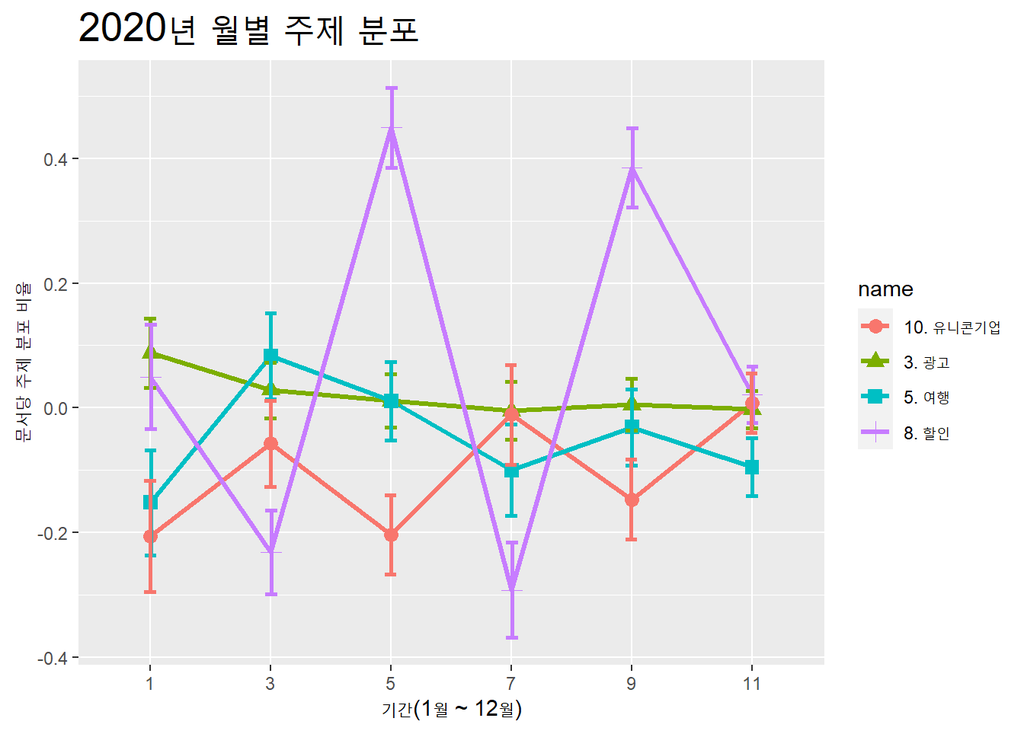

```r
term_coef_time2020 %>%
  mutate(term = str_extract(term, "\\d$")) %>%
  mutate(term = as.integer(term)) %>%
  mutate(term = term * 2 - 1) %>%
  mutate(term = as.factor(term)) %>%

  filter(str_detect(name, "^3|^5|^8|^10")) %>%

  ggplot(aes(x = term,
             y = estimate,
             color = name)) +
  geom_line(aes(group = name), size = 1.2) +
  geom_point(aes(shape = name), size = 3,) +
  geom_errorbar(aes(ymin = estimate - std.error,
                    ymax = estimate + std.error),
                width = .4, size = 1,
                position = position_dodge(.01)) +
  labs(x = "기간(1월 ~ 12월)",
       y = "문서당 주제 분포 비율",
       title = "2020년 월별 주제 분포") +
  theme(plot.title = element_text(size = 20))
```

##### 2020년도

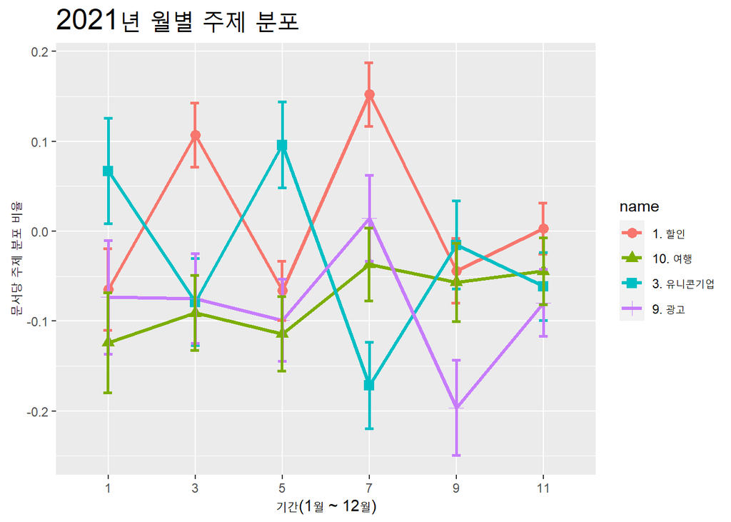

```r
term_coef_time2021 %>%
  mutate(term = str_extract(term, "\\d$")) %>%
  mutate(term = as.integer(term)) %>%
  mutate(term = term * 2 - 1) %>%
  mutate(term = as.factor(term)) %>%

  filter(str_detect(name, "^9|^10|^1|^3")) %>%

  ggplot(aes(x = term,
             y = estimate,
             color = name)) +
  geom_line(aes(group = name), size = 1.2) +
  geom_point(aes(shape = name), size = 3,) +
  geom_errorbar(aes(ymin = estimate - std.error,
                    ymax = estimate + std.error),
                width = .4, size = 1,
                position = position_dodge(.01)) +
  labs(x = "기간(1월 ~ 12월)",
       y = "문서당 주제 분포 비율",
       title = "2021년 월별 주제 분포") +
  theme(plot.title = element_text(size = 20))
```

##### 2021년도

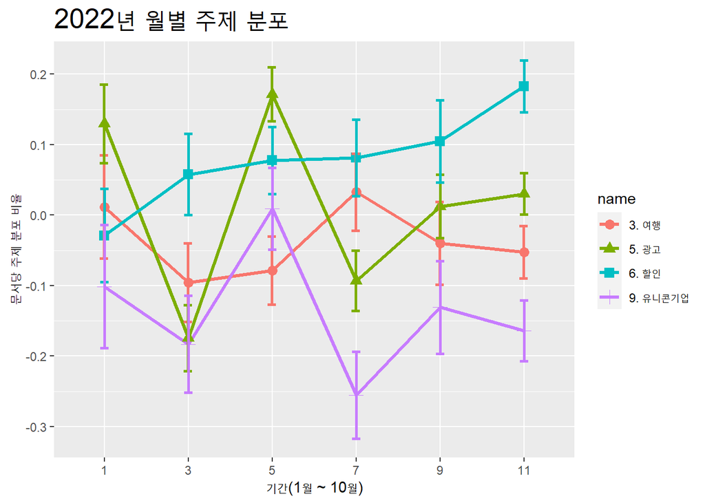

```r
term_coef_time2022 %>%
  mutate(term = str_extract(term, "\\d$")) %>%
  mutate(term = as.integer(term)) %>%
  mutate(term = term * 2 - 1) %>%
  mutate(term = as.factor(term)) %>%

  filter(str_detect(name, "^5|^3|^6|^9")) %>%

  ggplot(aes(x = term,
             y = estimate,
             color = name)) +
  geom_line(aes(group = name), size = 1.2) +
  geom_point(aes(shape = name), size = 3,) +
  geom_errorbar(aes(ymin = estimate - std.error,
                    ymax = estimate + std.error),
                width = .4, size = 1,
                position = position_dodge(.01)) +
  labs(x = "기간(1월 ~ 10월)",
       y = "문서당 주제 분포 비율",
       title = "2022년 월별 주제 분포") +
  theme(plot.title = element_text(size = 20))
```

##### 2022년도

**유니콘 기업**은 21년도와 마찬가지로 1월과 5월에 고점을 찍었지만 여름에 들어서며 줄어들었다.  
**광고**는 1월과 5월에 고점을 찍고 여름에 줄어들었다. 이는 4월 거리두기 해제와 함께 이벤트를 많이 실행한 것으로 보인다.  
**여행**은 22년도의 여행은 4월 이후부터 여름에 고점을 찍었고 이후에는 줄어들고 있다.  
**할인**은 22년은 할인의 시즌이다. 거리두기 해체와 함께 숙박업에서는 할인을 통한 차별점을 두기 위해 노력하고 있는 것으로 본인다.

## 4.정리

3년간의 연월별 주제의 변화추이를 살펴본 결과

**광고**는 20년 21년 모두 침체된 분위기를 보였다. 하지만 2022년에 들어서면서 주제 분포가 많아지기 시작했고 점차 증가하는 것으로 보인다.

**할인**은 년도마다 할인하는 월이 달랐다. 아마 프로모션의 형태가 소비자의 의해 결정되기 때문에 그런 것일 수도 있다고 본다. 2022년도에 들어서면서 할인과 관련된 내용은 매우 많아졌는데 이는 앞서 말했듯이 엔데믹의 영향이 있을 가능성이 높다.